# Decision tree building, Pruning 2

lec7-1

hanbyeol true  
04-16-2021

# decision tree building, Purnning 방법

### 패키지 불러오기!

*rpart.plot* : tree 시각화 하는 패키지

```r
library(ISLR)
library(tidyverse)
library(MASS)
library(rpart)
library(rpart.plot)
```

### Boston data를 이용할거야!

```r
attach(Boston)
Boston %>% dim()
```

```
[1] 506  14
```

```r
Boston %>% head()
```

```
     crim zn indus chas   nox    rm  age    dis rad tax ptratio
1 0.00632 18  2.31    0 0.538 6.575 65.2 4.0900   1 296    15.3
2 0.02731  0  7.07    0 0.469 6.421 78.9 4.9671   2 242    17.8
3 0.02729  0  7.07    0 0.469 7.185 61.1 4.9671   2 242    17.8
4 0.03237  0  2.18    0 0.458 6.998 45.8 6.0622   3 222    18.7
5 0.06905  0  2.18    0 0.458 7.147 54.2 6.0622   3 222    18.7
6 0.02985  0  2.18    0 0.458 6.430 58.7 6.0622   3 222    18.7
   black lstat medv
1 396.90  4.98 24.0
2 396.90  9.14 21.6
3 392.83  4.03 34.7
4 394.63  2.94 33.4
5 396.90  5.33 36.2
6 394.12  5.21 28.7
```

### Building decision tree

- *rpart()*: regression 할때는 *lm()*에 넣었는데 decision tree에서는 *rpart()* 함수에 넣음
- method : rpart에서는 method=“anova”로 regression을 적용
- cp : anova split일 때: 나눌 때마다 R^2가 증가할텐데, 증가하는 정도를 어느정도로 할것인지 cp가 높을수록 tree구조가 단순해진다
- minbucket : terminal node가 몇 개 일 때까지 building 할거닝?

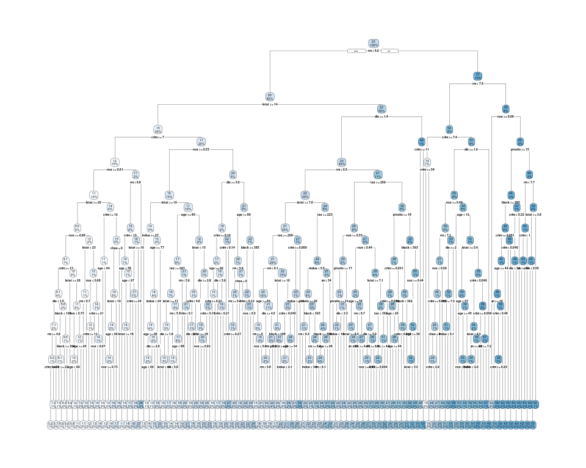

```r
boston_tree <- rpart(medv ~ .,
                     data = Boston,
                     method = "anova",
                     control = rpart.control(
                       cp = 0,
                       minbucket = 1,
                       maxdepth = 10))
rpart.plot(boston_tree)
```

헤엑 이렇게 가지들이 많을수록 오버피팅의 문제가 있다 .. 그래서 prunig 필요하다!

### Pruning

*rpart.control* 함수에 자동으로 xval하는 것이 저장되어있음(validation 진행)

```r
class(boston_tree$cptable)
```

```
[1] "matrix" "array"
```

matrix니까

검정: cp에 따라서 rel error가 어떻게 바뀌는지(train set에 대한 error값-쭉 떨어짐)

빨강: cp에 따라서 cross val가 어떻게 바뀌는지(cross validation에 대한 error값-가장 낮은 시점부터 overfitting이 시작됨)

cp값에 따라서 prune 할 수 있다

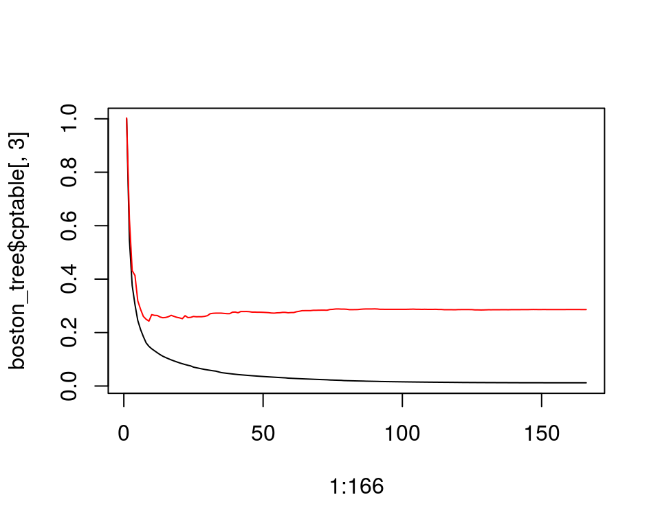

```r
plot(1:166, boston_tree$cptable[,3], type = "l")
points(1:166, boston_tree$cptable[,4],type = "l", col="red")
```

```r
printcp(boston_tree)
```

```
Regression tree:
rpart(formula = medv ~ ., data = Boston, method = "anova", control = rpart.control(cp = 0,
    minbucket = 1, maxdepth = 10))

Variables actually used in tree construction:
 [1] age     black   chas    crim    dis     indus   lstat   nox
 [9] ptratio rm      tax     zn

Root node error: 42716/506 = 84.42

n= 506

            CP nsplit rel error  xerror     xstd
1   4.5274e-01      0  1.000000 1.00312 0.083217
2   1.7117e-01      1  0.547256 0.62438 0.057842
```

[output cut: 164 more lines]

split할수록 rel error가 작아짐(train data에 대해서 학습을 더 잘한다고 볼 수 있음)

xerror: cross validation error: train data로 학습할 때 xerror가 감소하다가 overfit되는 지점부터는 다시 증가함

우리의 목적: cp중에서 cross validarion이 작고, 오버피팅되지 않은 값을 찾기를 원함

cp중에서 cross validarion이 작은 것이 어디있니: -> *which.min()*:index를 찾아내고 그때의 cp값을 잡아옴

```r
bestcp <- boston_tree$cptable[which.min(boston_tree$cptable[,"xerror"]),"CP"]
```

위에서 정한 cp를 기준으로 prune을 해라.

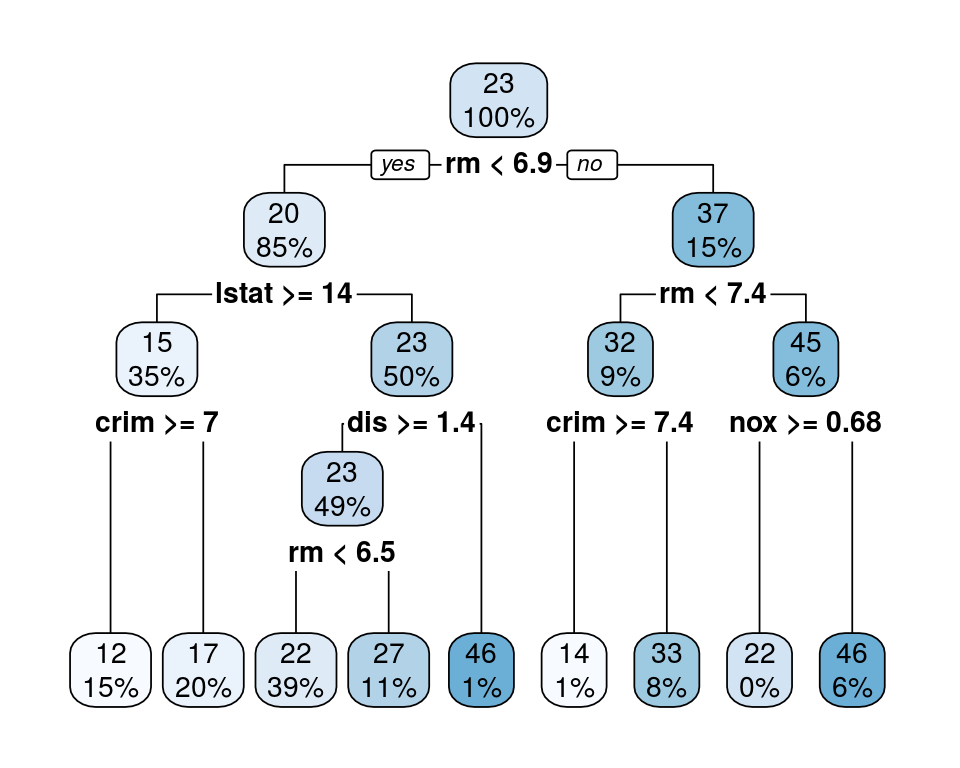

```r
best_boston_tree <- prune(boston_tree, cp = bestcp)
rpart.plot(best_boston_tree)
```

아까보다는 가지 숱이 없어진 것을 볼 수 있다!

# 결론!

복잡한 tree에서 prune을 하는 이유: optimal tree를 찾는 것이 목적인데,

Gini index와 Entropy를 기준으로 설정하는 것보다 cp를 이용해서 pruning을 하는 방법이

좋은 tree를 찾는다고 알려져있음(in textbook)

+남들에게 설명해주기 편함(현상해석을 분석할 때 어덯게 왜 작동하는지)

-> predict 모델에서는 이유를 설명하기 보다는 잘 추정하는 것이 더 중요함